# Code for our Paper "Keep it Simple: Evaluating Local Search-based Latent Space Editing"

## Andreas Meißner, Andreas Fröhlich and Michaela Geierhos

# Local Search Algorithm

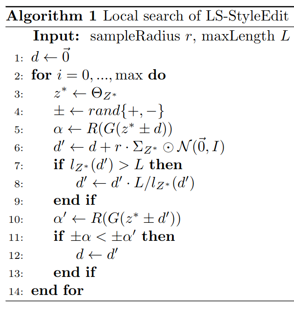

```python
from IPython.display import Image
Image("jupyter_imgs/local_search_pseudocode.png", width=400)
```

- d is our attribute vector which the algorithm tries to optimize such that it changes a target attribute as much as possible
- Since the different latent spaces follow different distributions, we use Θ_Z* to denote a general sampling function that returns a random latent vector according to the corresponding distribution of Z∗
- Σ_Z* is the standard deviation of each element of the latent space over 1000 samples
- l_Z* is torch.norm(d'/Σ_Z)
- the code for W-space can be found here LS-StyleEdit_W.py
- the code for S-space can be found here LS-StyleEdit_S.py

# Figure 4, Plotting the distribution of StyleGAN2's W- and S-Space

```python
import sys
sys.path.append("./tmp_styleclip")

import pickle
import dnnlib
import click
import legacy
import torch
import numpy as np
from training.networks import SynthesisNetwork,SynthesisBlock,SynthesisLayer,ToRGBLayer
import types
import pandas as pd
import seaborn as sns
import matplotlib.pyplot as plt

n_regressor_predictions = 40 # the regressor is pretrained on CelebA and predicts 40 face attributes
device = 'cuda:0'
batch_size = 1
truncation_psi = 0.5
noise_mode = 'const'
network_pkl =  './pretrained_models/ffhq.pkl'

def LoadModel(network_pkl,device):
    with dnnlib.util.open_url(network_pkl) as fp:
        G = legacy.load_network_pkl(fp)['G_ema'].requires_grad_(False).to(device) # type: ignore

    G.synthesis.forward=types.MethodType(SynthesisNetwork.forward,G.synthesis)
    G.synthesis.W2S=types.MethodType(SynthesisNetwork.W2S,G.synthesis)

    for res in G.synthesis.block_resolutions:
        block = getattr(G.synthesis, f'b{res}')
        # print(block)
        block.forward=types.MethodType(SynthesisBlock.forward,block)

        if res!=4:
            layer=block.conv0
            layer.forward=types.MethodType(SynthesisLayer.forward,layer)
            layer.name='conv0_resolution_'+str(res)

        layer=block.conv1
        layer.forward=types.MethodType(SynthesisLayer.forward,layer)
        layer.name='conv1_resolution_'+str(res)

        layer=block.torgb
        layer.forward=types.MethodType(ToRGBLayer.forward,layer)
        layer.name='toRGB_resolution_'+str(res)


    return G

G = LoadModel(network_pkl, device)
label = torch.zeros([1, G.c_dim], device=device)
```

```python
sns.set_style("darkgrid")
plt.rc("axes", titlesize=18)
plt.rc("axes", labelsize=14)
plt.rc("xtick", labelsize=13)
plt.rc("ytick", labelsize=13)
plt.rc("legend", fontsize=13)
plt.rc("font", size=13)
```

## w-Space

```python
z = torch.from_numpy(np.random.RandomState(0).randn(1, G.z_dim)).to(device)
w0 = G.mapping(z,label, truncation_psi=truncation_psi)[:, 0, :]
for random_seed in range(1, 1000):
    z = torch.from_numpy(np.random.RandomState(random_seed).randn(1, G.z_dim)).to(device)
    w = G.mapping(z,label, truncation_psi=truncation_psi)[:, 0, :]
    w0 = torch.cat([w0, w], axis=0)
```

```python
data = {"w_index": range(512), "std_w_index": w0.std(axis=0).detach().cpu().numpy()}
df = pd.DataFrame(data)
plt.figure(figsize=(10,6), tight_layout=True)
ax = sns.scatterplot(data=df, x="w_index", y="std_w_index", s=60)
plt.savefig("std_w_index.png")
```

[output not shown]

## StyleSpace

```python
z = torch.from_numpy(np.random.RandomState(0).randn(1, 512)).to(device)
w = G.mapping(z,label, truncation_psi=truncation_psi)
s=G.synthesis.W2S(w)
d = torch.zeros(1, 9088)
i=0
for key in s.keys():
    d[0:, i:i+s[key].shape[1]] = s[key]
    i+=s[key].shape[1]
```

```python
z = torch.from_numpy(np.random.RandomState(random_seed).randn(1, G.z_dim)).to(device)
w0 = G.mapping(z,label, truncation_psi=truncation_psi)
s=G.synthesis.W2S(w0)
d0 = torch.zeros(1, 9088)

i=0
for key in s.keys():
    d0[0:, i:i+s[key].shape[1]] = s[key]
    i+=s[key].shape[1]

for random_seed in range(1, 1000):
    z = torch.from_numpy(np.random.RandomState(random_seed).randn(1, G.z_dim)).to(device)
    w = G.mapping(z,label, truncation_psi=truncation_psi)
    w0 = torch.cat([w0, w], axis=0)
    s=G.synthesis.W2S(w)
    d = torch.zeros(1, 9088)
    i=0
    for key in s.keys():
        d[0:, i:i+s[key].shape[1]] = s[key]
        i+=s[key].shape[1]

    d0 = torch.cat([d0, d], axis=0)
```

```python
data = {"s_index": range(9088), "std_s_index": d0.std(axis=0).detach().cpu().numpy()}
df = pd.DataFrame(data)
plt.figure(figsize=(10,6), tight_layout=True)
ax = sns.scatterplot(data=df, x="s_index", y="std_s_index", s=30, edgecolor="none")
plt.savefig("std_s_index.png")
```

[output not shown]

# Table 3

# Figure 5 and 6

```python
'''
create .txt files for 1000 images (seed 0..999),
change the attribute smiling iterativly from -6..6 * smiling_attr_vector
save the scaling factor,
smiling prediction for the shifted image,
mean attribute change of all other attributes,
and cosine distance of a vgg embedding in the .txt files
'''

import os
from os import listdir
from os.path import isfile, join
from natsort import natsorted
import sys
stylegan2_path = './stylegan2-ada-pytorch'
sys.path.append(stylegan2_path)

import dnnlib
import click
import legacy
import torch
import numpy as np
from PIL import Image
from scipy.spatial.distance import cosine
import torch.nn.functional as F
from scipy.spatial.distance import cosine

n_regressor_predictions = 40 # the regressor is pretrained on CelebA and predicts 40 face attributes
device = 'cuda:0'
batch_size = 1
truncation_psi = 0.5
noise_mode = 'const'
network_pkl =  './pretrained_models/ffhq.pkl'

with dnnlib.util.open_url(network_pkl) as f:
    G = legacy.load_network_pkl(f)['G_ema'].to(device) # stylegan2-generator

with dnnlib.util.open_url(network_pkl) as f:
    D = legacy.load_network_pkl(f)['D'].to(device)

label = torch.zeros([1, G.c_dim], device=device)

def initialize_model():
    from facenet_pytorch import MTCNN, InceptionResnetV1
    resnet = InceptionResnetV1(pretrained='vggface2').to(device).eval()
    return resnet

face_rec = initialize_model()

import pickle
file_to_read = open("./pretrained_models/resnet_092_all_attr_5_epochs.pkl", "rb")
regressor = pickle.load(file_to_read)
regressor.eval()
file_to_read.close()

# smiling
attr_vec = torch.load("./attribute_vectors/l_vec_our_old_approach_smile_w.pt", map_location=device)

def get_face_embed(img):
    img_org_np = np.uint8(np.clip(((img.cpu().numpy() + 1) / 2.0) * 255, 0, 255))
    org = Image.fromarray(np.transpose(img_org_np[0], (1,2,0)))
    reshaped_org = org.resize((160, 160))
    reshaped_org = torch.Tensor(np.transpose(np.array(reshaped_org), (2,0,1))).to(device).unsqueeze(0)
    embed_org = face_rec(reshaped_org)
    return embed_org

def eval_linearity(attr_vec, attr_index, path):
    for random_seed in range(1000):
        z = torch.from_numpy(np.random.RandomState(random_seed).randn(batch_size, 512)).to(device)
        w = G.mapping(z,label, truncation_psi=truncation_psi)
        img_orig = G.synthesis(w, noise_mode=noise_mode)
        img_orig = F.interpolate(img_orig, size=256)
        pred_orig = regressor(img_orig)
        embed_orig = get_face_embed(img_orig)

        with open(path + '/seed_' + str(random_seed) + '.txt', 'w') as f:
            for i in range(-150,151):
                scaling_coeff = i/25
                img_shifted = G.synthesis(w-attr_vec*(scaling_coeff), noise_mode=noise_mode)
                img_shifted = F.interpolate(img_shifted, size=256)
                pred_shifted = regressor(img_shifted)
                #print(scaling_coeff, pred_shifted[0,31].item())
                embed_shifted = get_face_embed(img_shifted)
                similarity = cosine(embed_orig.detach().cpu().numpy(), embed_shifted.detach().cpu().numpy())
                other_pred_org = np.hstack([pred_orig[:, :int(attr_index)].cpu().numpy(), pred_orig[:, int(attr_index + 1):].cpu().numpy()])
                other_pred_shifted = np.hstack([pred_shifted[:, :int(attr_index)].cpu().numpy(), pred_shifted[:, int(attr_index + 1):].cpu().numpy()])

                attr_preservation = np.mean(np.abs(other_pred_org - other_pred_shifted))
                f.write(f"{scaling_coeff};{pred_shifted[0,attr_index].item()};{attr_preservation};{similarity}\n")

with torch.no_grad():
    eval_linearity(attr_vec_ours_bs8_smile, 31, './figure_5_6/')
```

Given the text files created with the above script, figure 5 and 6 can be created with Script for figure 5 and 6

## Training of our own CelebA-Classifier

Script to train or own CelebA-Classifier

## Algorithm 2, 3 and Table 4

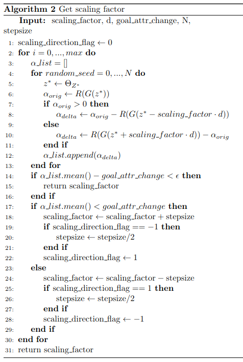

```python
Image("jupyter_imgs/scaling_factor_algo.png", width=400)
```

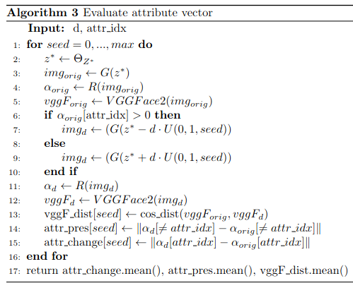

```python
Image("jupyter_imgs/eval_algo.png", width=400)
```

Script scale the length of the attribute vectors, and evaluate in Z- and W-Space

Script scale the length of the attribute vectors, and evaluate in S-Space

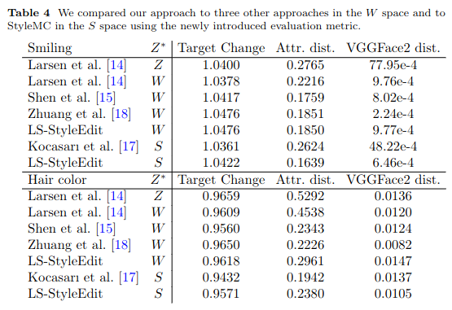

```python
Image("jupyter_imgs/results.png", width=400)
```